# M504 - AI And Applications

### Q4: Which gender category buys the most units and contributes most to revenue?

#### Ans4: Mens have given the most contribution in revenue

```python
gender_summary = df_copy.groupby("Gender_Category")[["Units_Sold", "Revenue"]].sum()
print("Units Sold & Revenue by Gender Category:\n", gender_summary)
```

```
Units Sold & Revenue by Gender Category:
                  Units_Sold    Revenue
Gender_Category
Kids                 1658.0  193129.23
Men                  1684.0  261454.48
Women                1618.0  232600.58
```

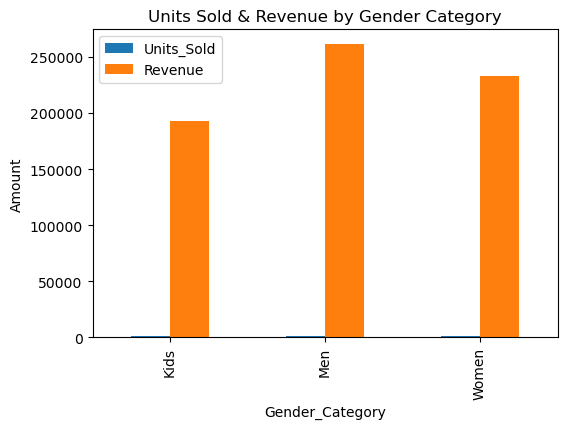

```python
gender_summary.plot(kind="bar", figsize=(6,4))
plt.title("Units Sold & Revenue by Gender Category")
plt.ylabel("Amount")
plt.show()
```

### Q5: Do discounts increase sales volume or hurt profitability?

#### Ans. Discounts hardly affect sales volume or profit, according to the correlation results (correlation values are very near to 0). This shows that using discounts in this dataset has little or no effect on profitability or a large increase in units sold.

```python
discount_corr = df_copy[["Discount_Applied", "Units_Sold", "Profit"]].corr()
print("Correlation between Discount, Units Sold & Profit:\n", discount_corr)
```

```
Correlation between Discount, Units Sold & Profit:
                   Discount_Applied  Units_Sold    Profit
Discount_Applied          1.000000    0.016417  0.008582
Units_Sold                0.016417    1.000000  0.009701
Profit                    0.008582    0.009701  1.000000
```

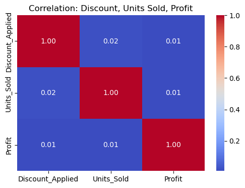

```python
plt.figure(figsize=(6,4))
sns.heatmap(discount_corr, annot=True, cmap="coolwarm", fmt=".2f")
plt.title("Correlation: Discount, Units Sold, Profit")
plt.show()
```

## Q6: What product sizes are most popular?

```python
size_summary = df_copy.groupby("Size")[["Units_Sold", "Revenue"]].sum().sort_values("Units_Sold", ascending=False)
print("Units Sold & Revenue by Size:\n", size_summary)
```

```
Units Sold & Revenue by Size:
       Units_Sold    Revenue
Size
L         1024.0   94954.89
XL        1001.0  151540.85
M          950.0  159883.71
7          183.0   42740.38
10         150.0   10350.77
11         145.0   20556.59
9          135.0   14950.20
12         127.0     328.47
8          120.0   16137.23
6          110.0   18023.50
```

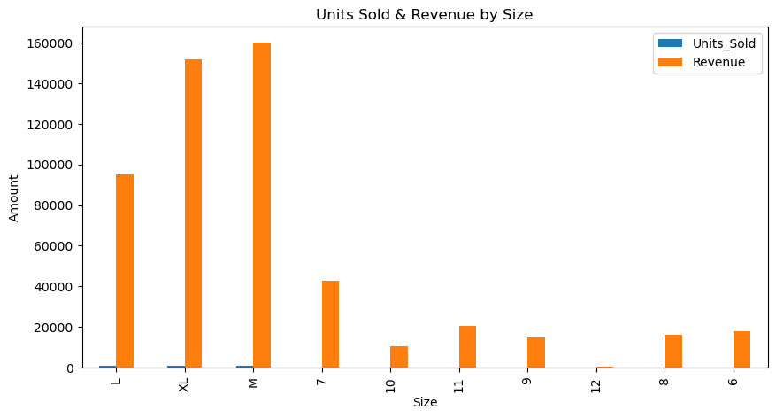

```python
size_summary.plot(kind="bar", figsize=(10,5))
plt.title("Units Sold & Revenue by Size")
plt.ylabel("Amount")
plt.show()
```

## Conclusion and Discussion

#### I used a disorganized, unclean Nike sales dataset for this project and then turned it into meaningful knowledge. Cleaning the data, examining trends, and assessing the effects of variables like sales channels, product sizes, and discounts on business results were the primary goals.

#### I determined from the analysis that discounts had no impact on raising profitability or sales volume. This means that discounts may not always equate to improved sales performance, even though they may grab attention. Larger product sizes, particularly L, M, and XL, were the most popular with consumers and brought in the big amount of money, according to another significant discovery. Nike may be able to maximize inventory by concentrating more on sizes with high demand if smaller sizes contributed less.

#### All things considered, this project demonstrated how unstructured corporate data can be processed, cleansed, and examined to get insightful information. Such information is useful for companies like Nike, a global brand, when it comes to pricing, promotions, and inventory planning.